# CAT simulations

Norwegian CDI:WG Comprehension

# Setup

Below are the settings for the analyses reported in this document.

```r
language <- "Norwegian"
scale <- "WG Comprehension" # one of "WG Comprehension", "WG Production", "WG Gestures", "WS"
```

Plot titles, file names etc. are based on them.

Please make sure the subtitle of this document and the filename are consistent with these settings (language and scale). Other than that do not change the code or text in the document (unless you know what you are doing). No code modifications should be required to successfully run the code (and eventually knit the document), as long as you knitted the corresponding `fit-*.Rmd` file first.

The following libraries are loaded.

```r
library(beepr)
library(tidyverse)
library(mirtCAT)
library(parallel)
#library(ggpubr)
```

Functions from “Functions” directory are sourced. Data are expected and saved in “Data” directory.

## Data loading

There are four key objects needed for all the analyses done and presented here:

1. IRT model (`mod`)
2. `responses` matrix (administrations x items; 0/1), used for the final model (`mod`) fitting
3. `cdi` data frame (items with their definitions & glosses), used for the final model (`mod`) fitting
4. `scores` data frame (participant information: raw scores & demographics)

# Model exploration

## IRT items parameters

We use a scatterplot to plot item parameters (*we use English glosses; also, if we had categories we could add them as colours*).

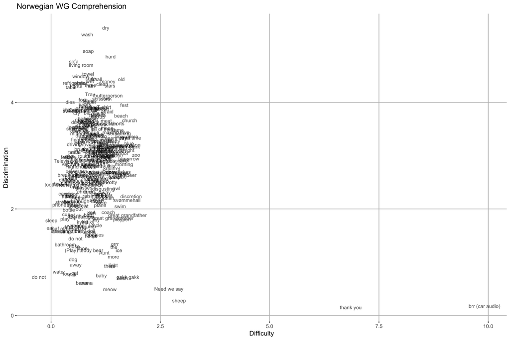

## Ability vs raw scores

We compute ability estimates ($\theta$’s) for children from the sample.

**NB:** For some datasets (models) the computation does not converge: should be looked into (does it have something to do with the chosen MAP method?).

We plot estimated abilities ($\theta$’s) against raw scores (sums of checked items).

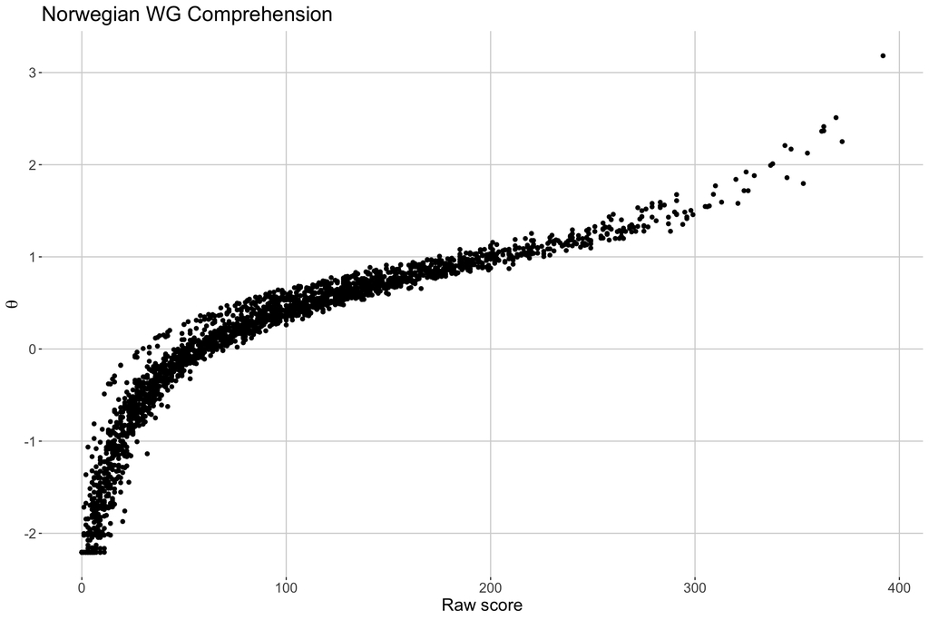

The scatterplot above shows that IRT estimates get “normalised”, compared to raw scores. The same can be seen comparing the following histograms.

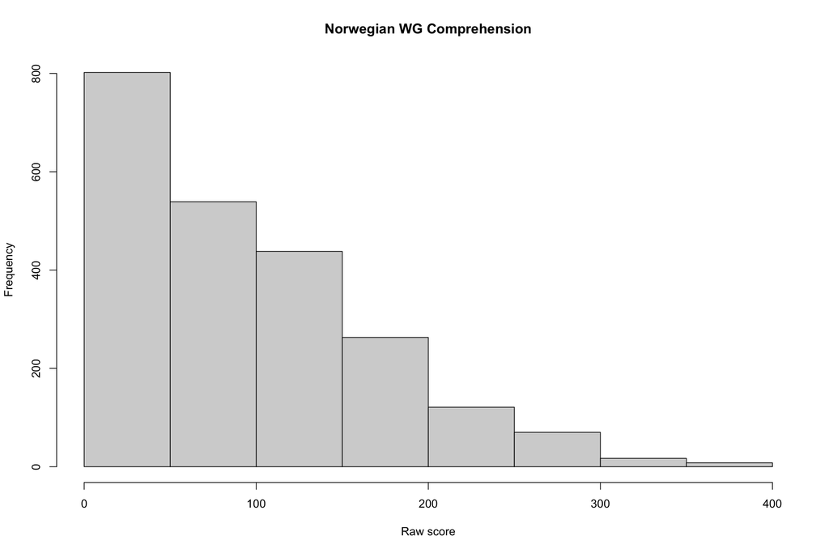

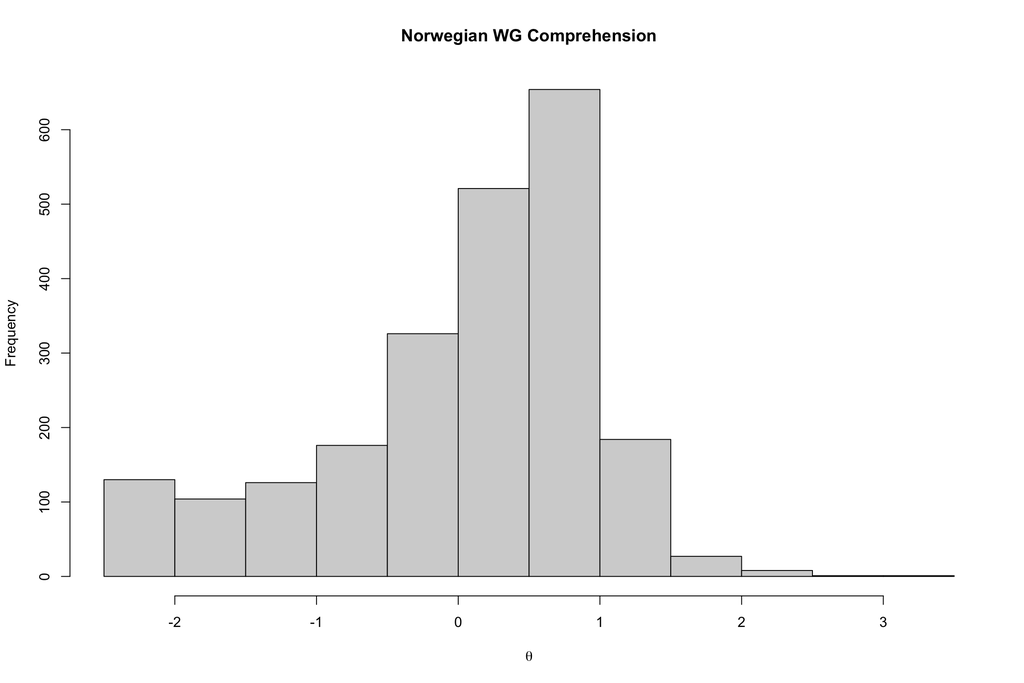

## Ability vs SE

We plot ability estimates against their standard errors.

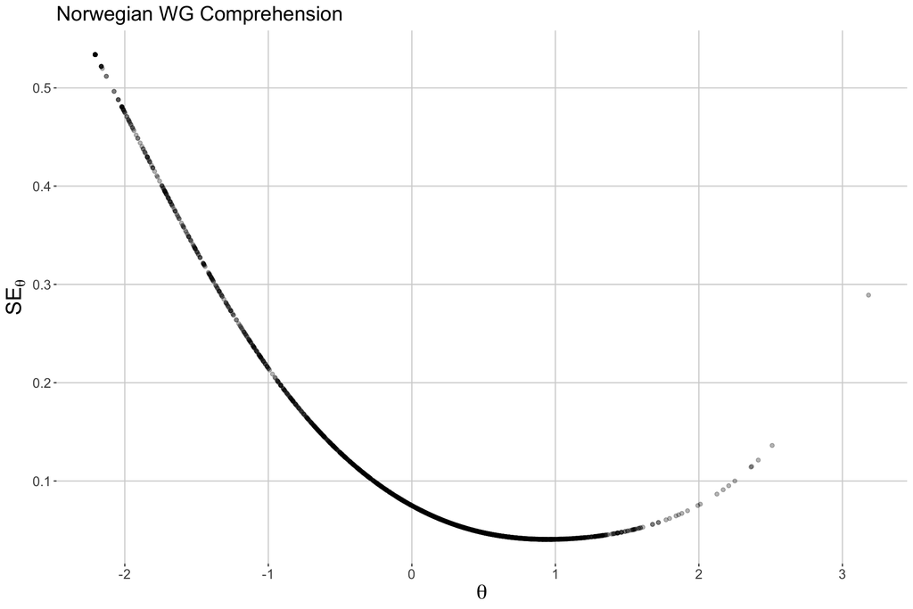

The scatterplot above shows increasing errors at both extremes of the ability level (perhaps due to floor and ceiling effects). We also plot the distribution of SEs.

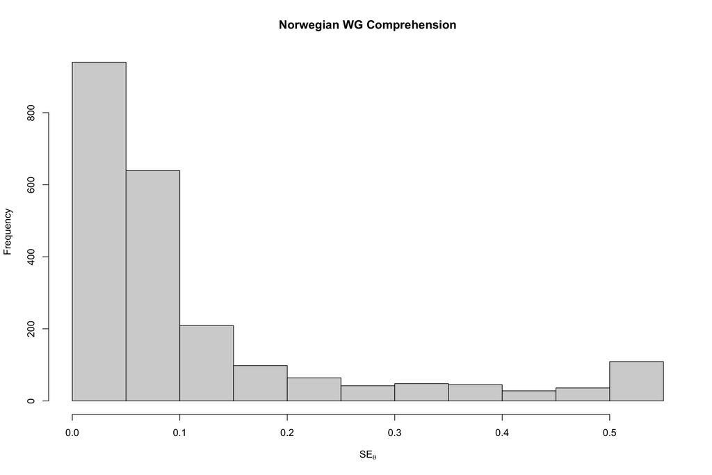

We can export the data for crosslinguistic plotting/analysing.

## SE and ability level vs age

The graph below shows distribution of standard errors by age.

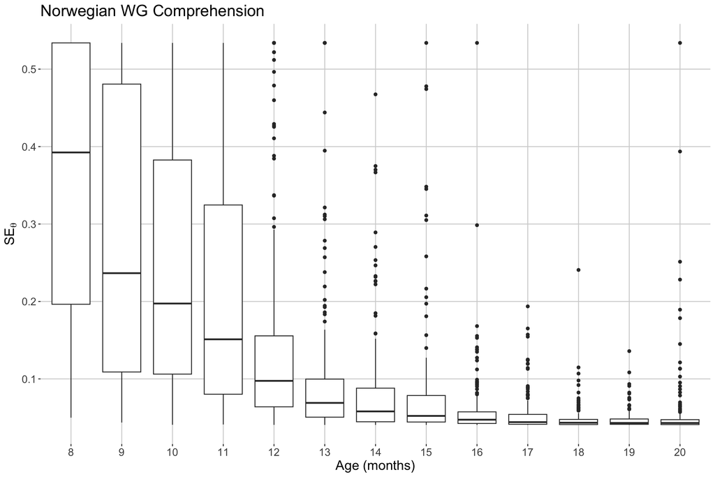

Now we plot the distribution of raw scores by age…

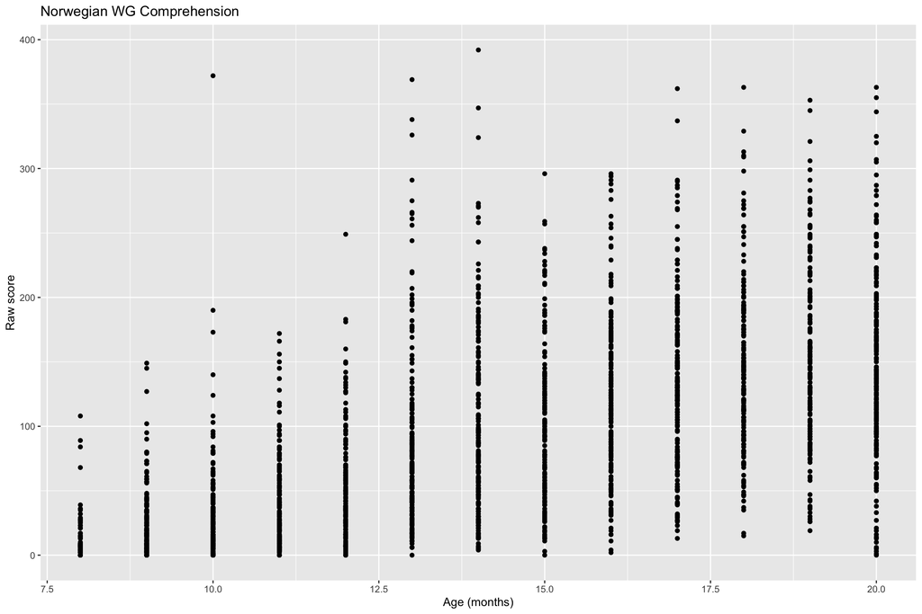

…and the distribution of ability by age with colour indicating the ability’s SE.

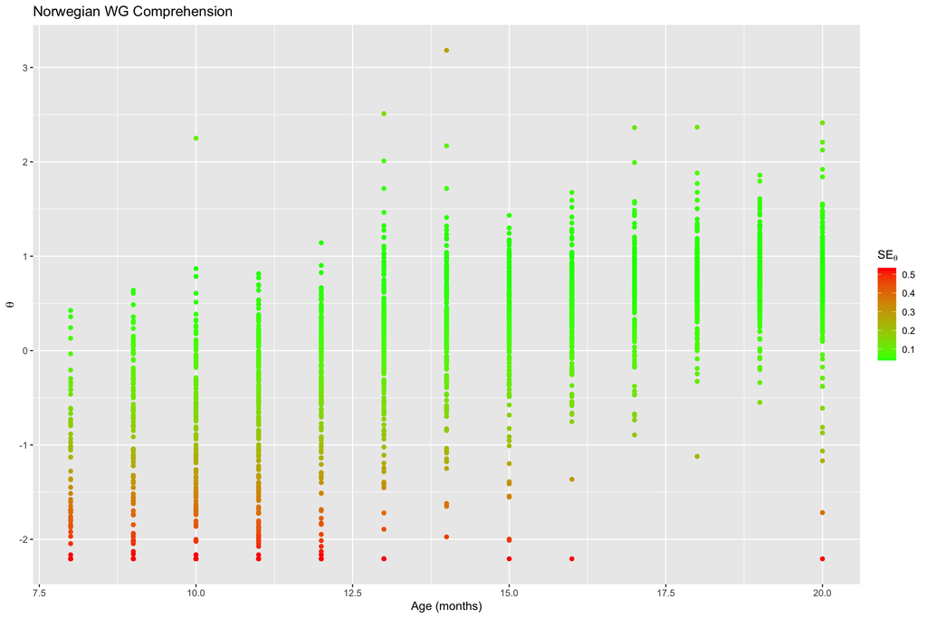

# Simulations

At the moment the simulations we run help us to decide CAT stopping criteria, max. $SE_{\theta}$ accepted and max. number of items allowed. We first observe how adding items decreases the mean $SE_{\theta}$ and we identify the $SE_{\theta}$ value, for which adding another item doesn’t result in a *substantial drop* anymore. Then we run simulations with that value as a stopping crietrion to see how many items are needed to reach this criterion for a *reasonably high* proportion of administrations.

```r
SE_delta <- 0.001 # non-substantial drop in mean SE
q_fail <- .2 # reasonably low proportion of administrations not reaching desired SE
```

## Whole pool for everyone

We simulate CAT administrations without any stopping criteria (and save the simulation results to “Data/norwegian_wg_comp_sim_all.RData” for later reuse).

```
## Mean length: 355; Median length: 355
## Correlation with all-item thetas: 1, with raw scores: 0.867
## Mean SE: 0.121; Reliability: 0.985
## Never used items: 0 out of all 355
```

Based on the whole pool simulation we can examine decreasing average $SE_{\theta}$ with each item.

We can export the data for crosslinguistic plotting/analysing.

We want to find the first value for which the difference between it and the next one is less than 0.001.

| mean_SE | test_length | diff |
| --- | --- | --- |
| 0.1746212 | 50 | -0.0009456107 |

We plot the average $SE_{\theta}$ by each consecutive item (max. 100: highly unlikely not to reach the plateau by then) and add red dashed lines marking the above.

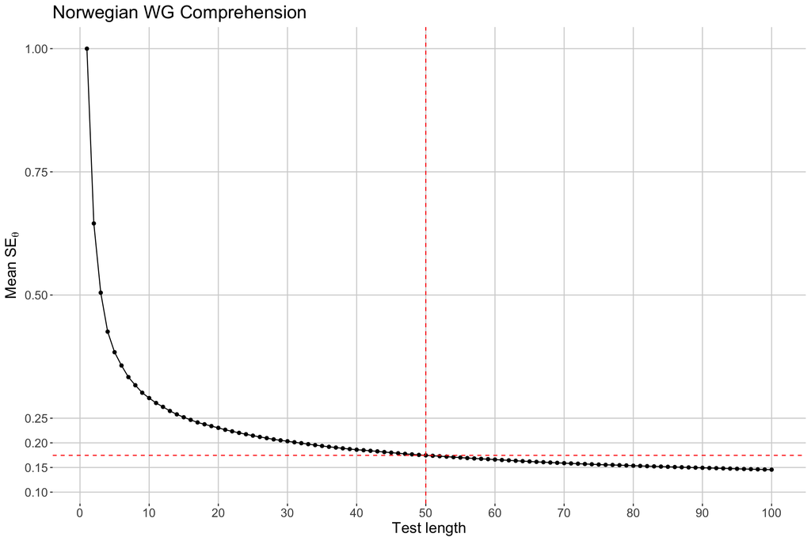

## $SE_{\theta} <$ 0.175 stop criterion

We simulate CAT again, this time stopping each administration when its $SE_{\theta}$ reaches 0.175.

```
## Mean length: 86.8; Median length: 14
## Correlation with all-item thetas: 0.974, with raw scores: 0.845
## Mean SE: 0.206; Reliability: 0.958
## Never used items: 0 out of all 355
```

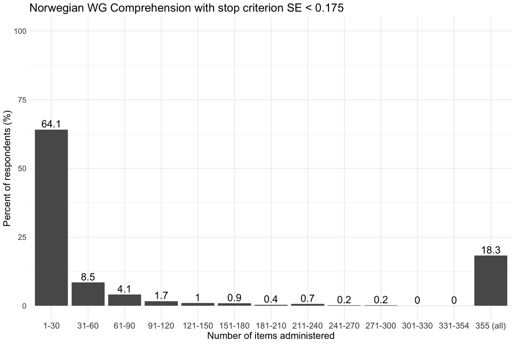

We want to find the number of items needed to leave only 0.2 of all administrations not reaching $SE_{\theta} <$ 0.175.

```
##   80%
## 171.8
```

# Config files preparation

For the CAT app to work we need two files, `items.csv` with parameter estimates and a question for each item, and `startThetas.csv` with $\theta_0$, either a single value or different values for different (combinations of) demographic (age and/or sex) variables.

$\theta_0$ values may be “corrected” (i.e., decreased by a set constant) to make it more likely for first items to be answered positively.

“Questions” for individual items may be used to display for each item its category, but they may also be more specific (which is important for gestures but might be helpful to keep track of the comprehension/production distinction as well).

The code chunk below, if run, creates two files: “Data/norwegian_wg_comp_items.csv” and “Data/norwegian_wg_comp_startThetas.csv”.

```r
start_thetas <- get_start_thetas(scores, "age", "sex", correction=.5)[[1]]
prepare_config_files(params, cdi$item_definition, fscores_aggr,
                     question = "CATEGORY LABEL here", group = subscale, id = cdi$item_id,
                     file1 = paste(filename_prefix, "items.csv", sep = "_"),
                     file2 = paste(filename_prefix, "startThetas.csv", sep = "_"))
```